# DESeq Notes ARC Project

Peter Fiorica

2025-07-16

```r
suppressPackageStartupMessages(library(data.table))
suppressPackageStartupMessages(library(tidyverse))
suppressPackageStartupMessages(library(DESeq2))
suppressPackageStartupMessages(library(gridExtra))
suppressPackageStartupMessages(library(ggExtra))
suppressPackageStartupMessages(library(readxl))
suppressPackageStartupMessages(library(ggrepel))
suppressPackageStartupMessages(library(DT))
suppressPackageStartupMessages(library(EnhancedVolcano))
suppressPackageStartupMessages(library(UpSetR))
suppressPackageStartupMessages(library(vsn))
library(ggforce)
"%&%"=function(a,b) paste(a,b,sep="")
arc_dir<- "/projects/rpci/songyao/pnfioric/arc_project/"
tils_dir <- "/projects/rpci/songyao/pnfioric/tils_r01_RNAseq/"

source("/projects/rpci/songyao/pnfioric/MultiEthnic_TILs_GWAS/Tractor/accessory_scripts/plotting.R")
```

# Introduction

This document serves as a template for running the DE analysis on the ARC data. It uses the TILs data as a template

# Step 0: Load functions

This chunk of code loads 2 main functions: one to perform the DE analysis and the other to pull the Bonferroni -significant genes from the results. Additionally, I loaded a few different plotting functions from the script I source when I load the package.

```r
#####
#

# DESeq Function
run_deseq_analysis <- function(count_data,
                               col_data, # Sample information
                               gene_info, # Gene annotation File
                               design_formula) {
  # Create DESeqDataSet from matrix
  dds <- DESeqDataSetFromMatrix(countData = count_data,
                                colData = col_data,
                                design = design_formula)

  # Run DESeq analysis
  dds <- DESeq(dds)
  IV <- resultsNames(dds)[2]
  print("Reporting results for expression related to: " %&% paste(IV))
  res <- results(dds, name = paste(IV))

  # Perform log fold change shrinkage using apeglm
  res <- lfcShrink(dds, coef = paste(IV), type = "apeglm")
  # Convert results to data.table
  output <- as.data.table(res@listData)
  output$gene_id <- res@rownames
  # Merge with gene_info
  output <- output %>% left_join(gene_info, by = c("gene_id" = "Gene stable ID version"))
  # Return the final output data.table
  return(output)
}

get_bonf_genes <-  function(dt) {
  dt %>%
    filter(pvalue < 0.05/nrow(dt)) %>%
    select(gene_id)
}
```

# Step 1: Load & Format data

The ARC data is loaded as a dds object, but below we will be loading the corresponding TIL data that relates to it.

```r
# Count Data
expected_count<-fread(tils_dir %&% "count_data/all_samples_expected_count.txt")

# Phenotypic Information (Coldata)
sample_info <-fread(tils_dir %&% "Phenotype_Sample_Info_wchs_nsbcs_pathways_w_tils_and_origsampetype_pam50_cibersort_iges_danaher_0506_2025.txt", header = T) %>% filter(stage!="0")

# Information about genes:
gene_info <- fread(tils_dir %&% "mart_export_gene_type.txt", header =T)


# Format the Coldata
coldata <- sample_info %>% # Using the sample_info object, we will format the data, so it selects the FASTQ ID (RS_ID), study and race, and tissue source
  select(RS_ID, Study=study, Race=race,ER, typeoforigsamples) %>% # We rename the race and study variable for downstream code, but it is not need as long as the downstream code is edited
  filter(Study != "Komen") %>% # Remove the non-tumor samples
  mutate(ER= if_else(ER=="ER+", "pos", # Re-label the ER variables as needed.
                     if_else(ER=="ER-", "neg", ER)))

rownames(coldata) <- coldata$RS_ID # Set the rownames as the FASTQ ID, which is the label of the count data.
```

Before going further, we can take a look at the structure of each file/object:

```r
expected_count[1:6, 1:10]
```

```
##               gene_id RS-04226224 RS-04226225 RS-04226226 RS-04226227
##                <char>       <num>       <num>       <num>       <num>
## 1: ENSG00000000003.16         945         970        1435         784
## 2:  ENSG00000000005.6         167          20        1415          67
## 3: ENSG00000000419.14         242         810         351         395
## 4: ENSG00000000457.14         945         787        1071         846
## 5: ENSG00000000460.17         381         721         609        4256
## 6: ENSG00000000938.13         467        1254         379        1019
##    RS-04226228 RS-04226229 RS-04226230 RS-04226231 RS-04226232
##          <num>       <num>       <num>       <num>       <num>
## 1:         374        2325         960         698        2001
## 2:           0          93           6          32          45
## 3:        1217        1068        1050         298         564
## 4:        1215        2245         882        1325        1433
## 5:        2268        2707        1448        2719        1012
## 6:         387        3949         769         839         267
```

```r
head(coldata)
```

```
##          RS_ID  Study   Race     ER typeoforigsamples
##         <char> <char> <char> <char>            <char>
## 1: RS-04246272  NSBCS  Black    pos              core
## 2: RS-04231161  NSBCS  Black    pos              core
## 3: RS-04246111  NSBCS  Black    pos              core
## 4: RS-04246047  NSBCS  White    pos              core
## 5: RS-04231062  NSBCS  White    neg              core
## 6: RS-04265731  NSBCS  White    pos              core
```

### Re-format data

Now, we need to reformat the data so that the RS_IDs match up across coldata and counts.

```r
expected_count_bc <- expected_count %>% select(gene_id, coldata$RS_ID)

# Split genes by LNC status

### This step was performed to separate the lncRNA's since Dr. Gong was working with that data, but it does not need to be performed for the ARC data.
non_lnc_gene_info <- gene_info %>% filter(`Gene type` != "lncRNA")
lnc_gene_info <- gene_info %>% filter(`Gene type` == "lncRNA")


# Gene Data Filtering
# This line tests if the value in a cell in a row is >5. It records it as 1 or 0. Row mean is >0.1, then it reports it in the object idx
# We are looking for genes wehere greater than 95% of the counts are five.
idx <- rowMeans(expected_count_bc == 5) > .95
expected_count_bc_filt <- expected_count_bc[!idx,]

# remove LNC rnas
expected_count_bc_filt <- expected_count_bc_filt %>% filter(!gene_id %in% lnc_gene_info$`Gene stable ID version`)
gene_list <- expected_count_bc_filt$gene_id


# Make into matrix for dds object
expected_count_bc_filt <- round(expected_count_bc_filt[,2:ncol(expected_count_bc_filt)])
print("There are " %&% nrow(expected_count_bc_filt) %&% " that pass the filters for our analysis.")
```

```
## [1] "There are 44117 that pass the filters for our analysis."
```

```r
expected_count_bc_filt <- as.matrix(expected_count_bc_filt)
rownames(expected_count_bc_filt) <- gene_list
```

# Step 2: Run differential expression analysis

### Method 1: Peter’s function

The simplest way to run DESeq2 at this point is to use the function I made. The function takes count data, coldata, gene annotation information, and a formula of covariates for regression.

This step takes a long time.

```r
output_race_no_er <- run_deseq_analysis(expected_count_bc_filt, coldata,
  gene_info = gene_info,
  design_formula = ~ Race + Study + typeoforigsamples)
```

```
## -- replacing outliers and refitting for 6884 genes
## -- DESeq argument 'minReplicatesForReplace' = 7
## -- original counts are preserved in counts(dds)
```

```
## [1] "Reporting results for expression related to: Race_White_vs_Black"
```

```
## using 'apeglm' for LFC shrinkage. If used in published research, please cite:
##     Zhu, A., Ibrahim, J.G., Love, M.I. (2018) Heavy-tailed prior distributions for
##     sequence count data: removing the noise and preserving large differences.
##     Bioinformatics. https://doi.org/10.1093/bioinformatics/bty895
```

Now, we can preview the results, and see that these results have generally everything we are looking for.

```r
head(output_race_no_er)
```

```
##      baseMean log2FoldChange       lfcSE    pvalue      padj            gene_id
##         <num>          <num>       <num>     <num>     <num>             <char>
## 1: 1801.71509   1.108112e-06 0.001442386 0.9418732 0.9757300 ENSG00000000003.16
## 2:   19.22876   4.098240e-06 0.001442673 0.3035874 0.5475419  ENSG00000000005.6
## 3:  882.76120  -1.428561e-05 0.001442036 0.5194607 0.7306783 ENSG00000000419.14
## 4: 1434.81647   1.088416e-05 0.001441868 0.6648560 0.8302354 ENSG00000000457.14
## 5: 1413.19027   1.330968e-06 0.001442263 0.9409943 0.9753429 ENSG00000000460.17
## 6:  383.75194   1.013568e-05 0.001442547 0.3535993 0.5981087 ENSG00000000938.13
##         Gene type Gene start (bp) Gene end (bp) Gene name
##            <char>           <int>         <int>    <char>
## 1: protein_coding       100627108     100639991    TSPAN6
## 2: protein_coding       100584936     100599885      TNMD
## 3: protein_coding        50934867      50959140      DPM1
## 4: protein_coding       169849631     169894267     SCYL3
## 5: protein_coding       169662007     169854080     FIRRM
## 6: protein_coding        27612064      27635185       FGR
##    Chromosome/scaffold name  Gene stable ID
##                      <char>          <char>
## 1:                        X ENSG00000000003
## 2:                        X ENSG00000000005
## 3:                       20 ENSG00000000419
## 4:                        1 ENSG00000000457
## 5:                        1 ENSG00000000460
## 6:                        1 ENSG00000000938
```

### Method 2: Formal way

This formal method deals with defining a dds object, which is the current format of the ARC data.

```r
# Define a counts variable... This is slightly redundant, but I am doing it for clarity's sake
count_data <- expected_count_bc_filt

# Define coldata variable
col_data <- coldata

# Define formula for regression
design_formula <- as.formula("~ Race + Study + typeoforigsamples")

dds <- DESeqDataSetFromMatrix(countData = count_data,
                                colData = col_data,
                                design = design_formula)
# Run DESeq analysis
dds <- DESeq(dds)
```

```
## -- replacing outliers and refitting for 6884 genes
## -- DESeq argument 'minReplicatesForReplace' = 7
## -- original counts are preserved in counts(dds)
```

```r
IV <- resultsNames(dds)[2]

# Perform log fold change shrinkage using apeglm
res <- lfcShrink(dds, coef = paste(IV), type = "apeglm")
```

```
## using 'apeglm' for LFC shrinkage. If used in published research, please cite:
##     Zhu, A., Ibrahim, J.G., Love, M.I. (2018) Heavy-tailed prior distributions for
##     sequence count data: removing the noise and preserving large differences.
##     Bioinformatics. https://doi.org/10.1093/bioinformatics/bty895
```

```r
# Convert Results into data.table
output <- as.data.table(res@listData)
# Make Gene ID for labels
output$gene_id <- res@rownames
```

Join the results to reference data.

```r
output <- output %>% left_join(gene_info, by = c("gene_id" = "Gene stable ID version"))

mod_mat <- model.matrix(design(dds), colData(dds))

head(mod_mat)
```

```
##             (Intercept) RaceWhite StudyPathways StudyWCHS
## RS-04246272           1         0             0         0
## RS-04231161           1         0             0         0
## RS-04246111           1         0             0         0
## RS-04246047           1         1             0         0
## RS-04231062           1         1             0         0
## RS-04265731           1         1             0         0
##             typeoforigsamples20micronslide typeoforigsamplescore
## RS-04246272                              0                     1
## RS-04231161                              0                     1
## RS-04246111                              0                     1
## RS-04246047                              0                     1
## RS-04231062                              0                     1
## RS-04265731                              0                     1
##             typeoforigsamplescurl
## RS-04246272                     0
## RS-04231161                     0
## RS-04246111                     0
## RS-04246047                     0
## RS-04231062                     0
## RS-04265731                     0
```

The model matrix (mod_mat) above will tell us which of the two options in the binary variable is our reference. In this situation, “RaceWhite” is being measured so the reference in “Black.” The changes below are differences observed in tumors from White Women relative to tumors from Black women

# Step 3: Visualize Results

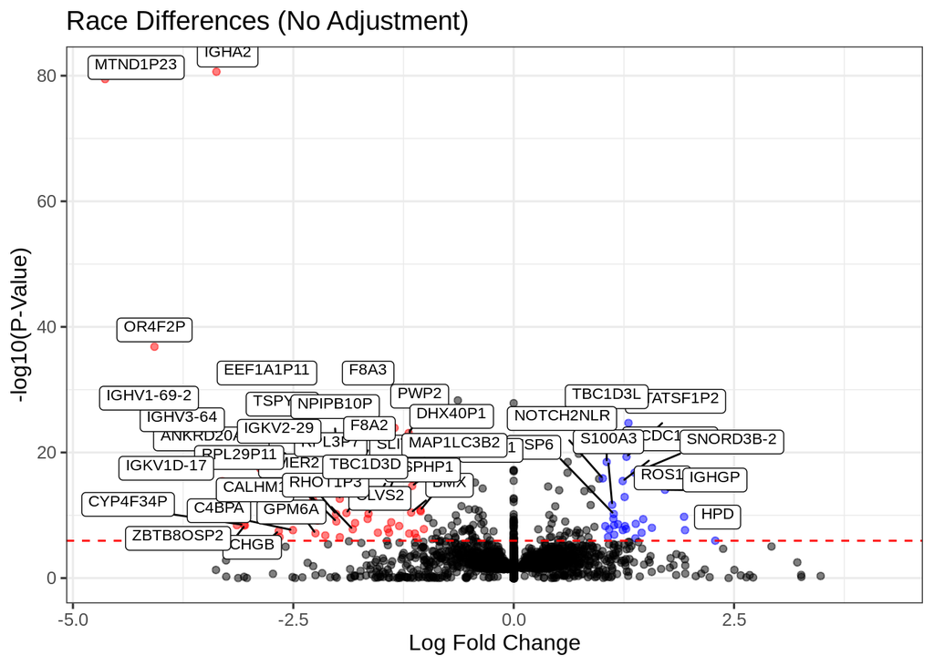

```r
volcano_plot(output,
             gene_name_col = "Gene name",
             hard_threshold = 1e-7,
             threshold = 0.05/nrow(output)) +ggtitle("Race Differences (No Adjustment)")
```